# Regresión lineal en series de tiempo

Author

RGA

Published

September 9, 2026

## 1 Regresión lineal

En el caso más simple, el modelo de regresión permite una relación lineal entre la variable a pronósticar $y$ y una única variable predictora $x$:

$$y_t = \beta_0+\beta_1x_t+\epsilon_t$$

El coeficientes $\beta_0$ y $\beta_1$ denotan el intercepto y la pendiente de la línea, respectivamente. El intercepto $\beta_0$ representa el valor predicho de $y$ cuando $x=0$. La pendiente $\beta_1$ representa el cambio promedio previsto en $y$ resultante de un aumento de una unidad en $x$.

### 1.1 Ejemplo

como calcular el modelo lineal, primero, debemos tener una hipótesis primaria en este caso, creemos con base en la teoría que, sí aumenta el ingreso, entonces debería aumentar el consumo de los hogares. Por lo tanto, nuestra hipotesís sería:

$$h_0: \beta_1>0$$
lo anterior es lo mismo que decir que si aumenta el ingreso, entonces, tendrá un impacto positivo en el consumo.

Revisamos los primero y últimos datos de la tabla de información.

chunk1

```r
head(uschange) #en la tarea remplazar por "datos"
```

```
        Consumption     Income Production   Savings Unemployment
1970 Q1   0.6159862  0.9722610 -2.4527003 4.8103115          0.9
1970 Q2   0.4603757  1.1690847 -0.5515251 7.2879923          0.5
1970 Q3   0.8767914  1.5532705 -0.3587079 7.2890131          0.5
1970 Q4  -0.2742451 -0.2552724 -2.1854549 0.9852296          0.7
1971 Q1   1.8973708  1.9871536  1.9097341 3.6577706         -0.1
1971 Q2   0.9119929  1.4473342  0.9015358 6.0513418         -0.1
```

```r
tail(uschange)
```

```
        Consumption    Income Production    Savings Unemployment
2015 Q2   0.7081439 0.9549595 -0.6970216  5.0239177         -0.1
2015 Q3   0.6649696 0.8016627  0.3806061  3.1809298         -0.3
2015 Q4   0.5616798 0.7400626 -0.8455464  3.4827860          0.0
2016 Q1   0.4046822 0.5190254 -0.4179305  2.2365341          0.0
2016 Q2   1.0477074 0.7237208 -0.2033188 -2.7215011         -0.1
2016 Q3   0.7295978 0.6447008  0.4749184 -0.5728579          0.0
```

chunk2

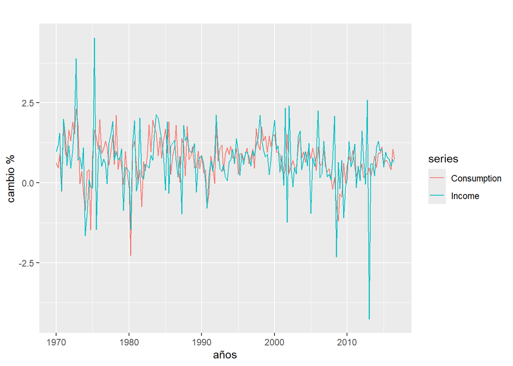

```r
autoplot(uschange[,c("Consumption","Income")])+  #la función c es para agrupar
  ylab("cambio %")+xlab ("años")
```

El coeficiente de correlación nos indica el grado de asociación lineal entre las dos variables numéricas,

chunk3

```r
#hay o no una relación linea?
cor(uschange[,c("Consumption","Income")])
```

```
            Consumption    Income
Consumption   1.0000000 0.3987795
Income        0.3987795 1.0000000
```

```r
cor.test(x = uschange[,c("Consumption")], y = uschange[,c("Income")])
```

```
    Pearson's product-moment correlation

data:  uschange[, c("Consumption")] and uschange[, c("Income")]
t = 5.9146, df = 185, p-value = 1.577e-08
alternative hypothesis: true correlation is not equal to 0
95 percent confidence interval:
 0.2707809 0.5129222
sample estimates:
      cor
0.3987795
```

La visualización del modelo lineal se muestra a continuación, donde el objetivo es ajustar una recta que minimice los errores al cuadrado, esto es, la distancia entre el valor calculado y el valor observado $\epsilon_t = y_t-\hat{y}\_t$

chunk4

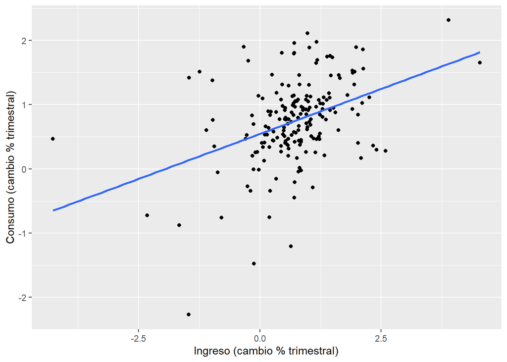

```r
uschange |>
  as.data.frame()|>
  ggplot(aes(x=Income,y=Consumption))+
  ylab("Consumo (cambio % trimestral)")+
  xlab("Ingreso (cambio % trimestral)")+
  geom_point()+
  geom_smooth(method="lm",se=FALSE)
```

```r
#geoom:smooth() usa la formula y - x
```

Un gráfico de dispersión de los cambios de consumo contra los cambios de ingresos se muestra en la figura de arriba, junto con la línea de regresión estimada.

$$\hat{y}_t=0.55+0.28x_t$$

(Pusimos un “sombrero” encima de $y$ para indicar que este es el valor de $y$ predicho por el modelo.)

chunk5

```r
tslm(Consumption ~ Income, data =uschange)
```

```
Call:
tslm(formula = Consumption ~ Income, data = uschange)

Coefficients:
(Intercept)       Income
     0.5451       0.2806
```

```r
summary(tslm(Consumption ~ Income, data =uschange))
```

```
Call:
tslm(formula = Consumption ~ Income, data = uschange)

Residuals:
     Min       1Q   Median       3Q      Max
-2.40845 -0.31816  0.02558  0.29978  1.45157

Coefficients:
            Estimate Std. Error t value Pr(>|t|)
(Intercept)  0.54510    0.05569   9.789  < 2e-16 ***
Income       0.28060    0.04744   5.915 1.58e-08 ***
---
Signif. codes:  0 '***' 0.001 '**' 0.01 '*' 0.05 '.' 0.1 ' ' 1

Residual standard error: 0.6026 on 185 degrees of freedom
Multiple R-squared:  0.159, Adjusted R-squared:  0.1545
F-statistic: 34.98 on 1 and 185 DF,  p-value: 1.577e-08
```

La línea ajustada tiene una pendiente positiva, que refleja la relación positiva entre el ingresos y el consumo. El coeficiente de la pendiente muestra que un incremento de una unidad en $x$ (un aumento de 1 punto porcentual en el ingreso personal disponible) resulta en promedio en un aumento de $0.28$ unidades en $y$ (un aumento promedio de $0.28$ puntos porcentuales en el gasto personal de consumo). Alternativamente, la ecuación estimada muestra que un valor de $1$ para $x$ (el aumento porcentual en la renta personal disponible) resultará en un valor pronosticado de $0.55+0.28*1=0.83$ para $y$ (el aumento porcentual del gasto en consumo personal).

La interpretación del intercepto requiere que un valor de $x=0$ tiene sentido. En este caso cuando $x=0$ (es decir, cuando no hay ningún cambio en la renta personal disponible desde el último trimestre) el valor previsto de $y$ es de $0.55$ (es decir, un aumento promedio del gasto en consumo personal de $0.55%$). Incluso cuando $x=0$ no tenga sentido, el intercepto es una parte importante del modelo. Sin ella, el coeficiente de pendiente se puede distorsionar innecesariamente. El intercepto debe incluirse siempre a menos que el requisito sea forzar la línea de regresión a través del origen. En lo que sigue suponemos que el intercepto siempre está incluida en el modelo.

### 1.2 Regresión lineal múltiple

Cuando hay dos o más variables predictoras, el modelo se llama un modelo de regresión múltiple. La forma general de un modelo de regresión múltiple es

$$y_t=β_0+β_1x_{1,t}+β_2x_{2,t}+\dots+β_kx_{k,t}+ε_t$$

donde $y$ es la variable a pronosticar y $x_1,\dots,x_k$ son las “k” variables de predictoras. Cada una de las variables predictoras debe ser numérica. Los coeficientes $\beta_1,\dots,\beta_k$ miden el efecto de cada predictor después de tener en cuenta los efectos de todos los demás predictores del modelo. Así, los coeficientes miden los efectos marginales de las variables predictores.

### 1.3 Supuestos

Cuando utilizamos un modelo de regresión lineal, estamos haciendo implícitamente algunas suposiciones sobre las variables en ecuación anterior.

En primer lugar, asumimos que el modelo es una aproximación razonable a la realidad; es decir, la relación entre la variable de pronóstico y las variables predictoras satisface esta ecuación lineal.

En segundo lugar, hacemos las siguientes suposiciones sobre los errores $(\epsilon_1,\dots,\epsilon_T)$:

- Tienen media cero; de lo contrario, los pronósticos se sesgarán sistemáticamente.
- No están autocorrelacionadas; de lo contrario, los pronósticos serán ineficientes, ya que hay más información en los datos que se pueden explotar.
- No están relacionadas con las variables predictoras; de lo contrario habría más información que debería incluirse en la parte sistemática del modelo.

También es útil tener los errores que normalmente se distribuyen con una varianza constante $\sigma^2$ con el fin de producir fácilmente intervalos de predicción.

Otra suposición importante en el modelo de regresión lineal es que cada predictor $x$ no es una variable aleatoria. Si estamos realizando un experimento controlado en un laboratorio, podríamos controlar los valores de cada $x$ (para que no fueran aleatorios) y observar los valores resultantes de $y$. Con datos observacionales (incluyendo la mayoría de los datos en negocios y economía), no es posible controlar el valor de $x$, simplemente los observamos. De ahí que hagamos de esto una suposición.

## 2 Mínimos cuadrados ordinarios

En la práctica, por supuesto, tenemos una colección de observaciones, pero no conocemos los valores de los coeficientes $\beta_0,\beta_1,\dots,\beta_k$. Estos deben estimarse a partir de los datos.

El principio de los mínimos cuadrados proporciona una forma de elegir los coeficientes de manera efectiva minimizando la suma de los errores cuadrados. Es decir, elegimos los valores de los $\beta_0,\beta_1,\dots,\beta_k$ que minimiza

$$\sum^{T}_{t=1}\epsilon^2_t=\sum^{T}_{t=1}(y_t-\beta_0-\beta_1x_{1,t}-\beta_2x_{2,t}-\dots-\beta_kx_{k,t})^2$$
Esto se llama estimación de mínimos cuadrados porque da el menor valor para la suma de errores cuadrados. Encontrar las mejores estimaciones de los coeficientes a menudo se llama “adaptar” el modelo a los datos, o a veces “aprender” o “entrenar” el modelo. La línea mostrada en la gráfica anterior se obtuvo de esta manera.

Cuando nos referimos a los coeficientes estimados, vamos a utilizar la notación $\hat\beta_0,\hat\beta_1,\hat\beta_2,\dots,\hat\beta_k$

La función tslm() se ajusta a un modelo de regresión lineal a los datos de series cronológicas. Es similar a la función lm() que se utiliza ampliamente para modelos lineales, pero tslm() proporciona configuraciones adicionales para la manipulación de series de tiempo.

## 3 Ejemplo: Gasto de consumo de EE.UU.

Un modelo de regresión lineal múltiple para el consumo de los EE.UU. es

$$y_t=\beta_0+\beta_1x_{1,t}+\beta_2x_{2,t}+\beta_3x_{3,t}+\beta_4x_{4,t}+\epsilon_t$$
donde $y$ es el cambio porcentual en el gasto real de consumo personal, $x_1$ es el cambio porcentual en la renta real disponible personal, $x_2$ es el cambio porcentual en la producción industrial, $x_3$ es el cambio porcentual en el ahorro personal y $x_4$ es el cambio en la tasa de desempleo.

El siguiente resumen proporciona información sobre el modelo calculado-ajustado. La primera columna de Coeficientes da una estimación de cada uno de ellos. El coeficiente y la segunda columna dan su error estándar (es decir, la desviación estándar que se obtendría de estimar repetidamente los coeficientes de los conjuntos de datos similares). El error estándar da una medida de la incertidumbre en el coeficiente estimado.

chunk6

```r
fit_conMR <- tslm(Consumption ~ Income + Production + Unemployment + Savings, data = uschange)
summary(fit_conMR)
```

```
Call:
tslm(formula = Consumption ~ Income + Production + Unemployment +
    Savings, data = uschange)

Residuals:
     Min       1Q   Median       3Q      Max
-0.88296 -0.17638 -0.03679  0.15251  1.20553

Coefficients:
             Estimate Std. Error t value Pr(>|t|)
(Intercept)   0.26729    0.03721   7.184 1.68e-11 ***
Income        0.71449    0.04219  16.934  < 2e-16 ***
Production    0.04589    0.02588   1.773   0.0778 .
Unemployment -0.20477    0.10550  -1.941   0.0538 .
Savings      -0.04527    0.00278 -16.287  < 2e-16 ***
---
Signif. codes:  0 '***' 0.001 '**' 0.01 '*' 0.05 '.' 0.1 ' ' 1

Residual standard error: 0.3286 on 182 degrees of freedom
Multiple R-squared:  0.754, Adjusted R-squared:  0.7486
F-statistic: 139.5 on 4 and 182 DF,  p-value: < 2.2e-16
```

A efectos de pronosticar, las dos columnas finales son de interés limitado. El “t value” es la relación del coeficiente estimado con su error estándar y la última columna da el “p value”: la probabilidad de que el coeficiente estimado sea tan grande como si no hubiera una relación real entre el consumo y el predictor correspondiente. Esto es útil cuando se estudia el efecto de cada predictor, pero no es particularmente útil para la predicción.

## 4 Valores ajustados

Predicciones de y puede obtenerse utilizando los coeficientes estimados en la ecuación de regresión y configurando el término de error a cero. En general, escribimos,

$$\hat{y_t}=\hat{\beta_0}+\hat{\beta}_1x_{1,t}+\hat{\beta}_2x_{2,t}+\dots+\hat{\beta}_kx_{k,t}$$

Introduciendo los valores de $x_{1,t},x_{k,t}$ para $t=1,...,T$ devuelve predicciones de $yt$ dentro de la muestra de entrenamiento, conocida como valores ajustados. Tenga en cuenta que se trata de predicciones de los datos utilizados para estimar el modelo, no los pronosticos reales de valores futuros de $y$.

Las siguientes gráficas muestran los valores reales en comparación con los valores ajustados para la variación porcentual en la serie de gastos de consumo de EE.UU. El gráfico temporal de la primer figura, muestra que los valores ajustados siguen los datos reales bastante de cerca. Esto se verifica por la fuerte relación positiva mostrada por el gráfico de disperción de la segunda figura.

chunk7

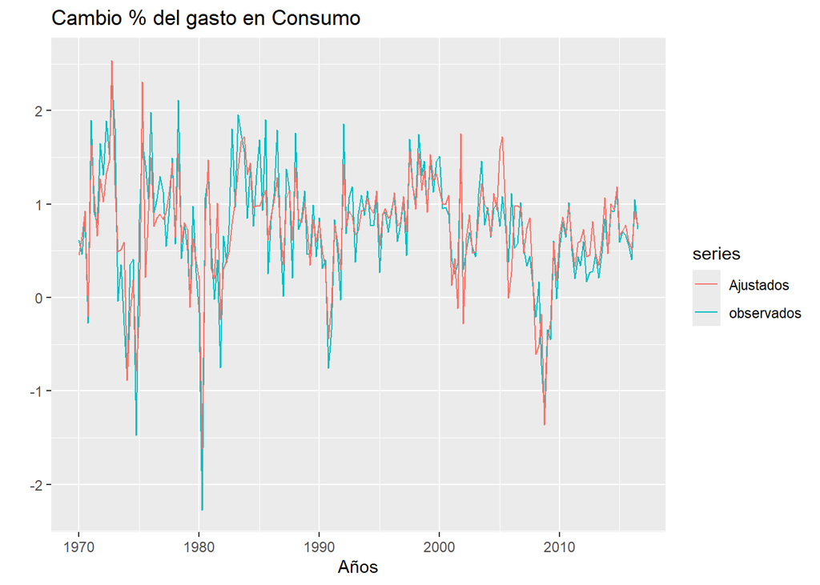

```r
autoplot(uschange[,"Consumption"], series = "observados")+
  autolayer(fitted(fit_conMR),series = "Ajustados")+
  xlab("Años") + ylab("")+
  ggtitle("Cambio % del gasto en Consumo")+
  guides(colou=guide_legend(""))
```

chunk8

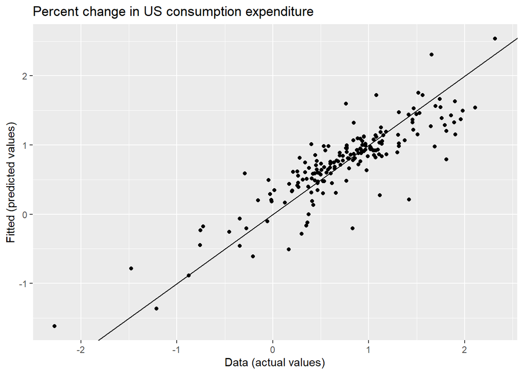

```r
cbind(Data = uschange[,"Consumption"],
      Fitted = fitted(fit_conMR)) %>%
  as.data.frame() %>%
  ggplot(aes(x=Data, y=Fitted)) +
    geom_point() +
    ylab("Fitted (predicted values)") +
    xlab("Data (actual values)") +
    ggtitle("Percent change in US consumption expenditure") +
    geom_abline(intercept=0, slope=1)
```

## 5 Bondad de ajuste R cuadrada

Una forma común de resumir lo bien que un modelo de regresión lineal encaja con los datos es a través del coeficiente de determinación, o $R^2$. Esto puede calcularse como el cuadrado de la correlación entre los valores observados $y$ y los valores predichos. Alternativamente, también se puede calcular como,

$$R^2=\frac{\sum(\hat{y}_t-\bar{y})^2}{\sum{y}_t-\bar{y})^2}$$
donde las sumas están sobre todas las observaciones. Así, la ecuacion refleja la proporción de variación en la variable de previsión que se contabiliza (o explica) el modelo de regresión.

En regresión lineal simple, el valor de $R^2$ es también igual al cuadrado de la correlación entre $y$ y $x$ (siempre que se haya incluido una interceptación).

Si las predicciones están cerca de los valores reales, esperaríamos $R^2$ estar cerca de 1. Por otro lado, si las predicciones no están relacionadas con los valores reales, entonces $R^2=0$ (una vez más, suponiendo que haya una interceptación). En todos los casos, $R^2$ se encuentra entre 0 y 1.

El valor de $R^2$ se utiliza con frecuencia, aunque a menudo incorrectamente, en la predicción. El valor de $R^2$ nunca disminuirá cuando se añade un predictor adicional al modelo y esto puede llevar a un exceso de ajuste. No hay reglas establecidas para lo que es un buen valor $R^2$, y los valores típicos de $R^2$ dependen del tipo de datos utilizados. Validar un rendimiento de pronóstico de modelo en los datos de ensayo es mucho mejor que la medición del valor de $R^2$ en los datos de formación.

## 6 Gráfico ACF de los residuos

Con los datos de series temporales, es muy probable que el valor de una variable observado en el período de tiempo más reciente sea similar a su valor en el período anterior, o incluso el período anterior, y así sucesivamente. Por lo tanto, al ajustar un modelo de regresión a los datos de series de tiempo, es común encontrar la autocorrelación en los residuos. En este caso, el modelo estimado viola la suposición de no autocorrelación en los errores, y nuestras previsiones pueden ser ineficientes. Hay alguna información que sobra sobre, dicha información debe ser contabilizada en el modelo con el fin de obtener mejores previsiones. Los pronósticos de un modelo con errores autocorrelacionados todavía son imparciales, por lo que no son “incorrectos”, pero por lo general tendrán intervalos de predicción más grandes de lo necesario. Por lo tanto, siempre debemos mirar el ACF de los residuos.

Otra prueba útil de autocorrelación en los residuos diseñada para tener en cuenta el modelo de regresión es la prueba Breusch-Godfrey, también conocida como la prueba LM (Lagrange Multiplier) para la correlación serie. Se utiliza para probar la hipótesis conjunta de que no hay autocorrelación en los residuos hasta un determinado orden especificado. Un pequeño valor de p indica que hay una autocorrelación significativa que queda en los residuos.

La prueba Breusch-Godfrey es similar a la prueba Ljung-Box, pero está diseñada específicamente para su uso con modelos de regresión.

La prueba de Breusch-Godfrey es una prueba estadística que detecta la autocorrelación en los residuos de un modelo de regresión. Se utiliza para validar supuestos de modelos de regresión de series de datos. La hipótesis nula es que no existe correlación serial de ningún orden hasta p. La prueba de Breusch-Godfrey también se conoce como Test del multiplicador de Lagrange de correlación serial de Breusch–Godfrey. Ejemplo, un valor p bajo (generalmente menor a 0.05) indica que es poco probable obtener los resultados observados si la hipótesis nula fuera cierta. Por lo tanto, rechazamos la hipótesis nula y concluimos que hay evidencia de autocorrelación en los residuos del modelo.

## 7 Histograma de residuos

Siempre es una buena idea comprobar si los residuos se distribuyen normalmente. Como hemos explicado anteriormente, esto no es esencial para la predicción, pero sí hace que el cálculo de los intervalos de predicción sea mucho más fácil.

## 8 Ejemplo

utilizando la función `checkresiduals`

chunk9

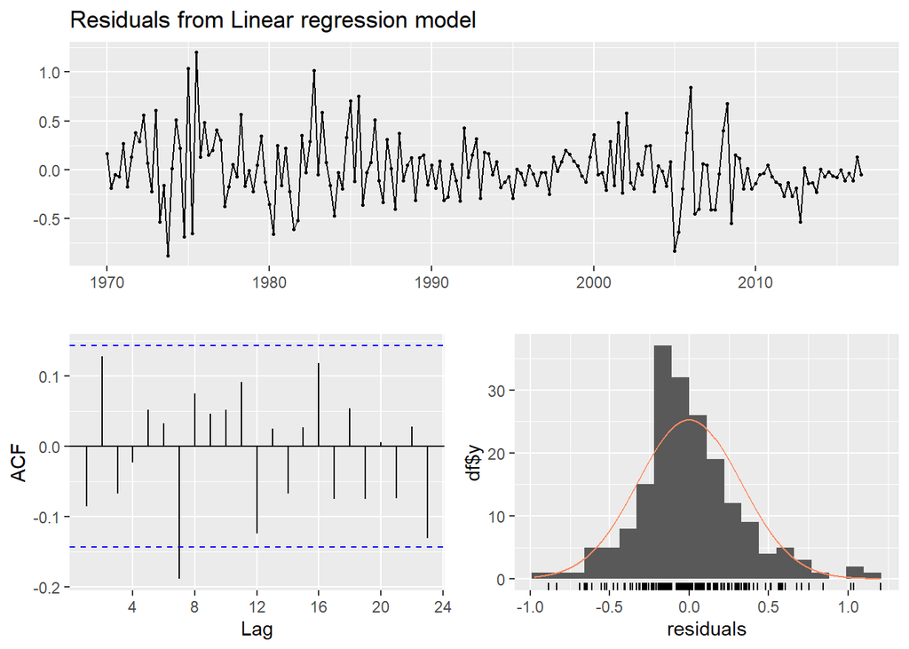

```
    Breusch-Godfrey test for serial correlation of order up to 8

data:  Residuals from Linear regression model
LM test = 14.874, df = 8, p-value = 0.06163
```

```r
checkresiduals(fit_conMR)
```

La figura de arriba muestra una gráfico de tiempo, la ACF y el histograma de los residuos del modelo de regresión múltiple instalado en los datos trimestrales de consumo de EE.UU., así como la prueba Breusch-Godfrey para pruebas conjuntas de hasta 8a autocorrelación. (La función de checkresiduals() utilizará la prueba Breusch-Godfrey para modelos de regresión, pero la prueba Ljung-Box de otra manera.)

La gráfica de tiempo muestra alguna variación cambiante con el tiempo, pero por lo demás es relativamente poco notable. Esta heteroscesticidad potencialmente hará inexacta la cobertura del intervalo de predicción.

El histograma muestra que los residuos parecen estar ligeramente sesgados, lo que también puede afectar la probabilidad de cobertura de los intervalos de predicción.

El gráfico de autocorrelación muestra un pico significativo a el rezago 7, pero no es suficiente para que la prueba de Breusch-Godfrey sea significativa en el nivel del 5%. En cualquier caso, la autocorrelación no es particularmente grande, y el rezago 7 es poco probable que tenga algún impacto notable en las previsiones o los intervalos de predicción.

## 9 Algunos predictores utiles

Hay varios predictores útiles que ocurren con frecuencia cuando se utiliza la regresión para los datos de series temporales.

### 9.1 Tendencia

Es común que los datos de las series temporales sean tendencia. Una tendencia lineal se puede modelar simplemente usando $x_{1,t}=t$ como predictor,

$$y_t=\beta_0+\beta_1t+\epsilon_t$$

donde $t=1,\dots,T$. Una variable de tendencia se puede especificar en la función tslm() usando el predictor de tendencias.

### 9.2 Variables Dummy

Hasta ahora, hemos asumido que cada predictor toma valores numéricos. Pero cuando un predictor es una variable categórica tomando sólo dos valores (por ejemplo, “sí” y “no’) Tal variable podría surgir, por ejemplo, a la hora de pronosticar las ventas diarias y se quiere tener en cuenta si el día es festivo o no. Así que el predictor toma valor en un día festivo, y”no” de otra manera.

Esta situación todavía se puede manejar en el marco de múltiples modelos de regresión mediante la creación de una variable “dummy” que toma valor 1 correspondiente a “sí” y 0 correspondiente a “no”. Una variable ficticia también se conoce como variable de indicador.

Una variable dummy también se puede utilizar para contabilizar un dato atípico (outlier). En lugar de omitir lo atípico, una variable ficticia elimina su efecto. En este caso, la variable ficticia toma valor 1 para esa observación y 0 en todas partes. Un ejemplo es el caso en que se ha producido un evento especial. Por ejemplo, a la hora de pronosticar las llegadas de turistas a Brasil, tendremos que dar cuenta del efecto de los Juegos Olímpicos de Río de Janeiro en 2016.

Si hay más de dos categorías, entonces la variable se puede codificar usando varias variables ficticias (una menos que el número total de categorías). tslm() manejará automáticamente este caso si especifica una variable factor como predictor. Por lo general, no hay necesidad de crear manualmente las variables ficticias correspondientes.

## 10 Variables dummy estacionales

Supongamos que estamos pronosticando datos diarios y queremos rendir cuentas del día de la semana como predictor. A continuación se pueden crear las siguientes variables ficticias (dummy).

[output not shown]

Observe que sólo se necesitan seis variables ficticias para codificar siete categorías. Esto se debe a que la séptima categoría (en este caso el domingo) es capturada por la interceptación, y se especifica cuando las variables ficticias están todas establecidas a cero.

Muchos principiantes intentarán añadir una séptima variable ficticia para la séptima categoría. Esto se conoce como la trampa de la variable dummy, porque causará que la regresión fracase. Habrá demasiados parámetros para estimar cuando también se incluya una interceptación. La regla general es utilizar una variable menos ficticia que las categorías. Así que, para los datos trimestrales, utilice tres variables ficticias; para datos mensuales, use 11 variables ficticias; y para los datos diarios, utilice seis variables ficticias, y así sucesivamente.

La interpretación de cada uno de los coeficientes asociados con las variables ficticias es que es una medida del efecto de esa categoría en relación con la categoría omitida. En el ejemplo anterior, el coeficiente de $d_{1,t}$ asociado al lunes medirá el efecto del lunes en la variable previsión respecto al efecto del domingo.

La función tslm() manejará automáticamente esta situación si especifica la temporada de predictores.

## 11 Pronósticos con regresión lineal

Cuando utilizamos modelos de regresión para datos de series temporales, tenemos que distinguir entre los diferentes tipos de pronósticos que se pueden producir, dependiendo de lo que se supone que se conoce cuando se calculan las previsiones.

Las previsiones *ex ante* son las que se hacen utilizando únicamente la información disponible con antelación. Por ejemplo, las previsiones *ex ante* para la variación porcentual del consumo de EE.UU. para trimestres posteriores al final de la muestra, solo deberían utilizar información disponible hasta 2016 Q3. Se trata de previsiones reales, realizadas de antemano utilizando cualquier información disponible en ese momento. Por lo tanto, para generar previsiones *ex ante*, el modelo requiere previsiones de los predictores. Para obtenerlos podemos utilizar uno de los métodos simples introducidos en la Sección de *modelos simples* o enfoques de series de tiempo puras más sofisticadas que siguen en los capítulos más adelante.

Las previsiones de *ex post* son las que se hacen utilizando información posterior sobre los predictores. Por ejemplo, las previsiones de consumo *ex post* pueden utilizar las observaciones reales de los predictores, una vez que se han observado. No se trata de previsiones reales, pero son útiles para estudiar el comportamiento de los modelos de previsión.

El modelo del que se producen las previsiones *ex post* no debe estimarse utilizando los datos del período previsto. Es decir, las previsiones a posteriori pueden asumir el conocimiento de las variables predictoras (el x variables), pero no debe asumir el conocimiento de los datos que se van a prever (el y variable).

Una evaluación comparativa de las previsiones *ex ante* y de las previsiones *ex post* puede ayudar a separar las fuentes de la incertidumbre prevista. Esto mostrará si los errores de previsión han surgido debido a las malas previsiones del predictor o debido a un mal modelo de previsión.

Los pronósticos ex ante son predicciones que se hacen antes de un evento, mientras que los pronósticos ex post son predicciones que se hacen después de un evento. Pronósticos ex ante

```
Se basan en la información disponible en el momento
```

Se usan en el mundo comercial para prever los resultados de acciones o series de acciones Se usan para definir metas y objetivos

Pronósticos ex post

```
Se basan en datos y resultados reales
```

Se usan para analizar los resultados de programas en el mediano o largo plazo Se usan para determinar si hubo desviaciones entre los escenarios ex ante y ex post

Ex ante y ex post en general

```
Ex ante significa "antes del evento"
```

Ex post significa “después del evento” Se usan en el control de gestión para referirse a diferentes momentos en el tiempo Se usan para definir variables económicas como el consumo, la inversión y el ahorro

## 12 Ejemplo: Producción de cerveza trimestral australiana

Normalmente, no podemos utilizar valores futuros reales de las variables predictoras cuando producimos pronósticos *ex-ante* porque sus valores no se conocerán de antemano. Sin embargo, los predictores especiales se conocen de antemano, ya que se basan en variables de calendario (por ejemplo, variables dummies estacionales o indicadores de días festivos) o funciones deterministas de tiempo (por ejemplo, tendencia temporal). En tales casos, no hay diferencia entre las previsiones *ex ante* y *ex post*.

chunk10

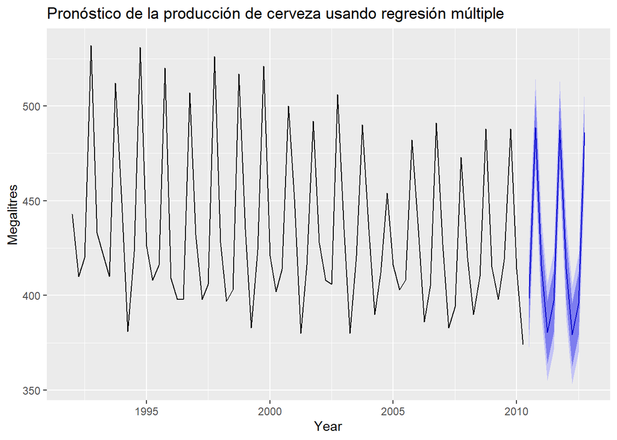

```r
beer2 <- window(ausbeer, start=1992)
fit_beer <- tslm(beer2 ~ trend + season)
fcast <- forecast(fit_beer)
autoplot(fcast) +
  ggtitle("Pronóstico de la producción de cerveza usando regresión múltiple")+
  xlab("Year") + ylab("Megalitres")
```

En la figura de arriba, los pronósticos del modelo de regresión para la producción de cerveza. La región sombreada oscura muestra intervalos de predicción del 80% y la región sombreada de luz muestra intervalos de predicción del 95%. Tenga en cuenta que la tendencia y la temporada no son objetos en el espacio de trabajo R; estos se crean automáticamente mediante tslm() cuando se especifican de esta manera.

## 13 Pronóstico basado en escenarios

En este escenario, el pronosticador asume posibles escenarios para las variables predictoras que son de interés. Por ejemplo, un creador de políticas o legislador de EE.UU. puede estar interesado en comparar el cambio previsto en el consumo cuando hay un crecimiento constante del 1% y del 0,5%, respectivamente, para los ingresos y ahorros, sin cambios en la tasa de empleo, frente a un descenso respectivo del 1% y del 0,5%, para cada uno de los cuatro trimestres tras el final de la muestra. Las previsiones resultantes se calculan a continuación y se muestran en la siguiente figura. Debemos tener en cuenta que los intervalos de predicción para las previsiones basadas en escenarios no incluyen la incertidumbre asociada con los valores futuros de las variables predictoras. Suponen que los valores de los predictores se conocen de antemano.

chunk11

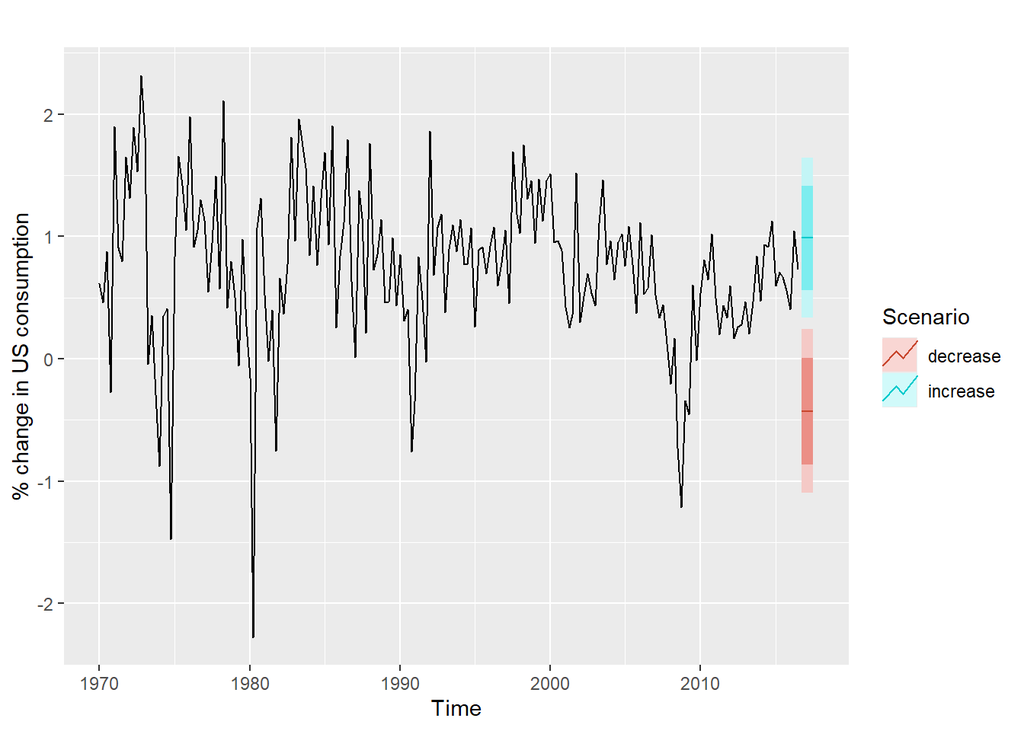

```r
fit.consBest <- tslm(
  Consumption ~ Income + Savings + Unemployment,
  data = uschange)
h <- 4
newdata <- data.frame(
    Income = c(1, 1, 1, 1),
    Savings = c(0.5, 0.5, 0.5, 0.5),
    Unemployment = c(0, 0, 0, 0))
fcast.up <- forecast(fit.consBest, newdata = newdata)
newdata <- data.frame(
    Income = rep(-1, h),
    Savings = rep(-0.5, h),
    Unemployment = rep(0, h))
fcast.down <- forecast(fit.consBest, newdata = newdata)

autoplot(uschange[, 1]) +
  ylab("% change in US consumption") +
  autolayer(fcast.up, PI = TRUE, series = "increase") +
  autolayer(fcast.down, PI = TRUE, series = "decrease") +
  guides(colour = guide_legend(title = "Scenario"))
```

## 14 Construyendo un modelo predictivo de regresión

La gran ventaja de los modelos de regresión es que se pueden utilizar para capturar relaciones importantes entre la variable de interés previsto y las variables predictoras. Un reto importante, sin embargo, es que para generar pronósticos *ex ante*, el modelo requiere valores futuros de cada predictor. Si la previsión basada en escenarios es de interés, estos modelos son extremadamente útiles. Sin embargo, si la predicción *ex-ante* es el foco principal, la obtención de previsiones de los predictores puede ser difícil (en muchos casos generar pronósticos para las variables predictoras puede ser más difícil de lo que pronostica directamente la variable de previsión sin usar predictores).

Una formulación alternativa es utilizar como predictores sus valores rezagados. Asumiendo que estamos interesados en generar una $h$ pasos en el futuro podremos escribir

$$y_{t+h}=\beta_0+\beta_1x_{1,t}+\dots+\beta_kx_{k,t}+\epsilon_{t+h}$$
para $h=1,2....$ el conjunto predictor se forma por valores de las $equis(x)$ que se observan $h$ períodos de tiempo antes de observar $y$. Por lo tanto, cuando el modelo estimado se proyecta en el futuro, es decir, más allá del final de la muestra $T$, todos los valores predictores están disponibles.

Incluir los valores rezagados de los predictores no sólo hace que el modelo sea operativo para generar fácilmente previsiones, sino que también lo hace intuitivamente atractivo. Por ejemplo, el efecto de un cambio de política con el objetivo de aumentar la producción puede no tener un efecto instantáneo en el gasto de consumo. Lo más probable es que esto ocurra con un efecto rezagado. Nos referimos a esto en la sección sobre *predictores utiles* cuando introducimos brevemente rezagos distribuidos como predictores.

## 15 Intervalos de predicción

Con cada pronóstico para el cambio en el consumo de la figura de lineas arriba, también se incluyen intervalos de predicción 95% y 80%. La formulación general de cómo calcular los intervalos de predicción para múltiples modelos de regresión se presenta en la [Sección 5.7 del libro fpp2](https://otexts.com/fpp2/regression-matrices.html).

Como esto implica álgebra de matriz avanzada que presentamos aquí el caso para calcular los intervalos de predicción para una regresión simple, donde un pronóstico se puede generar usando la ecuación,

$$\hat{y}=\hat{\beta}_0+ \hat{\beta}_1x$$
Suponiendo que los errores de regresión se distribuyan normalmente, un intervalo de predicción aproximado del 95% asociado a este pronóstico se da por

$$\hat{y}\pm1.96\hat{\sigma}_e\sqrt{1+\frac{1}{T}}+\frac{(x-\bar{x})^2}{(T-1)s_x^2}$$

donde $T$ es el número total de observaciones, $\bar{x}$ es la media de los valores observados $x$, el $s_x$ es la desviación estándar de los valores observados $x$ y $\hat{\sigma}_e$ es el error estándar de la regresión dada por Ecuación de regresión lineal. Del mismo modo, se puede obtener un intervalo de predicción del 80% sustituyendo 1.96 por 1.28. Otros intervalos de predicción se pueden obtener sustituyendo el 1.96 por el valor apropiado que figura en la Tabla [3.1](https://otexts.com/fpp2/prediction-intervals.html#tab:pcmultipliers). Si se utiliza R para obtener intervalos de predicción, se obtienen cálculos más exactos (especialmente para valores pequeños de $T$ de lo que se da por la Ecuación de regresión lineal.

Ecuación (5.4) muestra que el intervalo de predicción es más amplio cuando $x$ está lejos de $\bar{x}$. Es decir, estamos más seguros de nuestras previsiones a la hora de considerar valores de la variable predictora cercana a su media muestra.

### 15.1 Ejemplo

chunk12

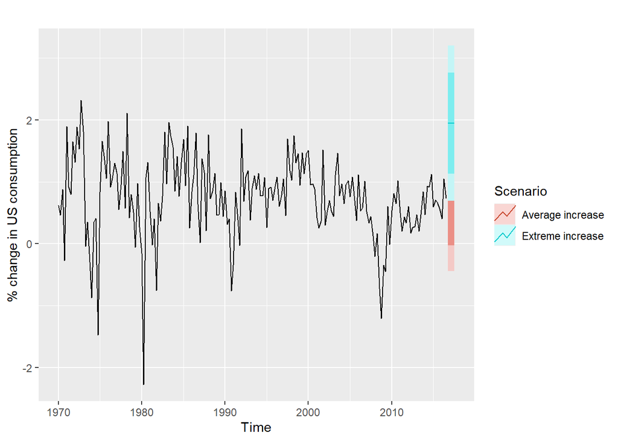

```r
fit.cons <- tslm(Consumption ~ Income, data = uschange)
h <- 4
fcast.ave <- forecast(fit.cons,
  newdata = data.frame(
    Income = rep(mean(uschange[,"Income"]), h)))
fcast.up <- forecast(fit.cons,
  newdata = data.frame(Income = rep(5, h)))
autoplot(uschange[, "Consumption"]) +
  ylab("% change in US consumption") +
  autolayer(fcast.ave, series = "Average increase",
    PI = TRUE) +
  autolayer(fcast.up, series = "Extreme increase",
    PI = TRUE) +
  guides(colour = guide_legend(title = "Scenario"))
```

## 16 Si sobra tiempo

```r
library(quantmod)
getSymbols('AMZN', src = 'yahoo',
           from = "2010-01-01", to = Sys.Date())
```

```
[1] "AMZN"
```

```r
Stock1 <- data.frame(
  AMZN,
  date = as.Date(rownames(data.frame(AMZN)))
)

getSymbols('NVDA', src = 'yahoo',
           from = "2010-01-01", to = Sys.Date())
```

```
[1] "NVDA"
```

```r
Stock2 <- data.frame(
  NVDA,
  date = as.Date(rownames(data.frame(NVDA)))
)
head(Stock2)
```

```
           NVDA.Open NVDA.High NVDA.Low NVDA.Close NVDA.Volume NVDA.Adjusted
2010-01-04   0.46275   0.46550  0.45275    0.46225   800204000     0.4232904
2010-01-05   0.46050   0.47400  0.46050    0.46900   728648000     0.4294715
2010-01-06   0.46875   0.47300  0.46425    0.47200   649168000     0.4322186
2010-01-07   0.46950   0.47150  0.45925    0.46275   547792000     0.4237483
2010-01-08   0.45900   0.46700  0.45625    0.46375   478168000     0.4246639
2010-01-11   0.46625   0.46825  0.45075    0.45725   556612000     0.4187119
                 date
2010-01-04 2010-01-04
2010-01-05 2010-01-05
2010-01-06 2010-01-06
2010-01-07 2010-01-07
2010-01-08 2010-01-08
2010-01-11 2010-01-11
```

```r
summary(Stock2)
```

```
   NVDA.Open         NVDA.High           NVDA.Low          NVDA.Close
 Min.   :  0.218   Min.   :  0.2263   Min.   :  0.2162   Min.   :  0.2220
 1st Qu.:  0.464   1st Qu.:  0.4698   1st Qu.:  0.4577   1st Qu.:  0.4635
 Median :  4.319   Median :  4.3670   Median :  4.2533   Median :  4.3027
 Mean   : 29.914   Mean   : 30.3983   Mean   : 29.3777   Mean   : 29.9038
 3rd Qu.: 21.251   3rd Qu.: 21.8650   3rd Qu.: 20.8890   3rd Qu.: 21.2975
 Max.   :233.110   Max.   :236.5400   Max.   :229.6300   Max.   :235.7400
  NVDA.Volume        NVDA.Adjusted           date
 Min.   :4.564e+07   Min.   :  0.2033   Min.   :2010-01-04
 1st Qu.:2.688e+08   1st Qu.:  0.4375   1st Qu.:2014-03-05
 Median :3.984e+08   Median :  4.2554   Median :2018-05-03
 Mean   :4.667e+08   Mean   : 29.8409   Mean   :2018-05-03
 3rd Qu.:5.774e+08   3rd Qu.: 21.2421   3rd Qu.:2022-07-03
 Max.   :3.693e+09   Max.   :235.4656   Max.   :2026-09-08
```

```r
date <- lubridate::ymd("2010-01-04")
decimal <- lubridate::decimal_date(date) # 2009.11
lubridate::date_decimal(decimal) # "2009-02-10 UTC"}
```

```
[1] "2010-01-04 00:00:00 UTC"
```

```r
decimal
```

```
[1] 2010.008
```

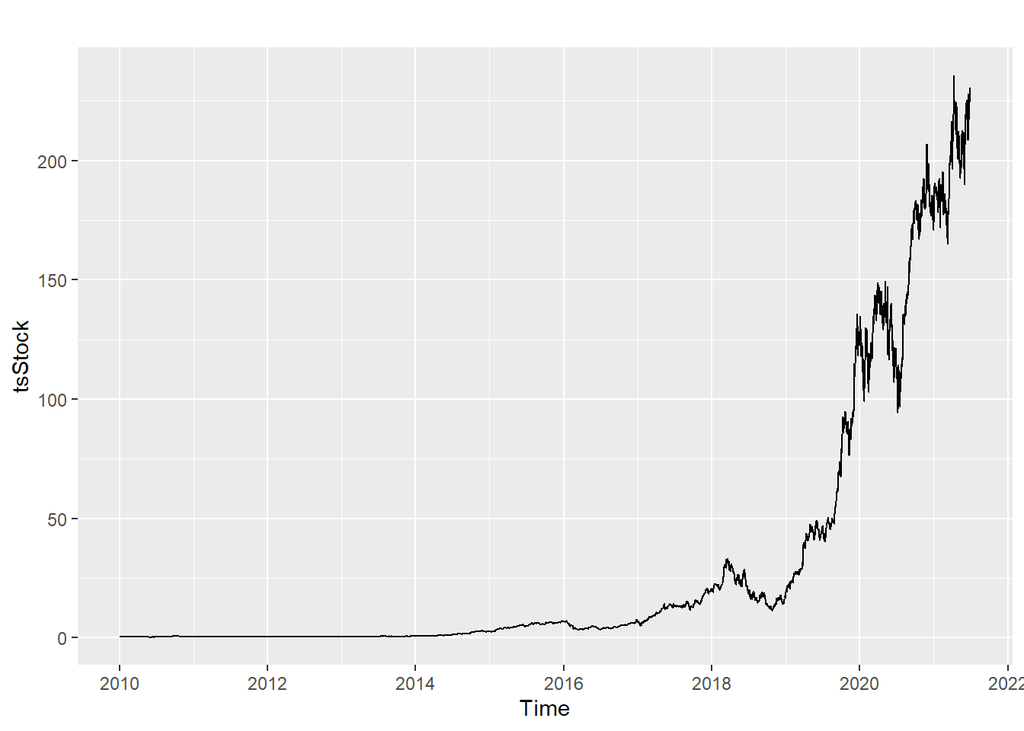

```r
tsStock <- ts(Stock2$NVDA.Close,start = 2010.008,frequency = 365.25)

autoplot(tsStock)
```